# Data Cleaning and Visualizations

## Understanding the Datasets

### Exploring the Fields (Columns) in the Dataset

You can use Python's libraries like pandas to load and explore the dataset. Begin by understanding the data types for each column, distinguishing between numerical, categorical, or text fields. Also, identify which columns represent dependent variables (target or output) and independent variables (features or input data).

```python
import pandas as pd

#Load the dataset
file_path = "C:\\Users\\rites\\OneDrive\\Desktop\\vehicles_dataset.csv"
data = pd.read_csv(file_path)
print(data)
```

```
                                                name  \
0                       2024 Jeep Wagoneer Series II
1                    2024 Jeep Grand Cherokee Laredo
2                           2024 GMC Yukon XL Denali
3                         2023 Dodge Durango Pursuit
4                              2024 RAM 3500 Laramie
...                                              ...
997   2024 Mercedes-Benz Sprinter 2500 Standard Roof
998           2024 Dodge Hornet Hornet R/T Plus Eawd
999                          2024 Jeep Wagoneer Base
1000           2024 Nissan Murano SV Intelligent AWD
1001                2024 Chevrolet Silverado 2500 WT

                                            description           make  \
0     \n      \n        Heated Leather Seats, Nav Sy...           Jeep
```

[output cut: 77 more lines]

### Brief Description of the Datasets

The vehicles dataset contains information about various cars, including specifications like mileage, engine size, fuel type, price, and more. This dataset can be used to analyze trends in vehicle efficiency, price range, or the correlation between different factors.

### Key Features of an Automotive Dataset

##### Make:

The manufacturer of the vehicle (e.g., Toyota, Ford, Honda).

##### Role:

Identifies the brand and can help in analyzing market trends based on brand popularity.

##### Model:

The specific name of the vehicle model (e.g., Camry, Mustang).

##### Role:

Useful for distinguishing between different vehicles produced by the same manufacturer.

##### Year:

The year the vehicle was manufactured.

##### Role:

Important for understanding trends over time, such as changes in pricing or fuel efficiency.

##### Price:

The selling price of the vehicle.

##### Role:

A crucial variable for market analysis and understanding consumer spending patterns.

##### Engine:

The engine of the vehicle's engine, often measured in liters (L).

##### Role:

Can be analyzed for its impact on fuel efficiency and performance.

##### Cylinders:

The number of cylinders in the engine.

##### Role:

Influences both power and fuel consumption; helps in classifying vehicle types.

##### Fuel (MPG):

The vehicle's miles per gallon (MPG) rating.

##### Role:

Indicates how fuel-efficient the vehicle is, a key factor for consumers.

##### Mileage:

The total distance the vehicle has traveled, often measured in miles.

##### Role:

Important for assessing vehicle wear and tear and resale value.

###### Transmission

Definition: The type of transmission (e.g., automatic, manual).

##### Role:

Affects driving experience and can influence consumer preference.

##### Body Style:

The physical configuration of the vehicle (e.g., coupe, hatchback).

##### Role:

Impacts consumer choice and marketing strategies.

##### Drivetrain:

The system that transmits power from the engine to the wheels (e.g., FWD, RWD, AWD).

##### Role:

Influences vehicle handling and performance characteristics.

##### Exterior Color:

The color of the vehicle's exterior.

##### Role:

Can be relevant for aesthetic preferences and market demand trends.

##### Interior Color:

The color of the vehicle's interior.

##### Role:

Similar to exterior color, impacts consumer preferences.

##### Trim:

The specific configuration or level of the vehicle, often indicating features and options included.

##### Role:

Helps in analyzing features and price variations within a model.

##### Safety Ratings:

Ratings given by safety organizations (e.g., NHTSA, IIHS).

##### Role:

Crucial for consumers when considering the safety of a vehicle.

### List of Fields and Definitions

#### Make:

The manufacturer of the vehicle (e.g., Toyota, Ford).

##### Model:

The specific model of the vehicle (e.g., Corolla, Mustang).

##### Year:

The manufacturing year of the vehicle.

##### Fuel Type:

Type of fuel used (e.g., Gasoline, Diesel, Electric).

##### Engine Size (L):

The engine displacement in liters.

###### Horsepower:

The power output of the vehicle's engine.

###### MPG (City/Highway):

Miles per gallon for city and highway driving.

##### Price:

The selling price of the vehicle.

##### Transmission:

Type of transmission (Automatic, Manual).

##### Drivetrain:

The system that transmits power to the wheels (e.g., FWD, AWD).

```python
print(data.head())
```

```
                              name  \
0     2024 Jeep Wagoneer Series II
1  2024 Jeep Grand Cherokee Laredo
2         2024 GMC Yukon XL Denali
3       2023 Dodge Durango Pursuit
4            2024 RAM 3500 Laramie

                                         description   make           model  \
0  \n      \n        Heated Leather Seats, Nav Sy...   Jeep        Wagoneer
1  Al West is committed to offering every custome...   Jeep  Grand Cherokee
2                                                NaN    GMC        Yukon XL
3  White Knuckle Clearcoat 2023 Dodge Durango Pur...  Dodge         Durango
4  \n      \n        2024 Ram 3500 Laramie Billet...    RAM            3500

  type  year    price                                             engine  \
```

[output cut: 19 more lines]

```python
print(data.info())
```

```
<class 'pandas.core.frame.DataFrame'>
RangeIndex: 1002 entries, 0 to 1001
Data columns (total 18 columns):
 #   Column          Non-Null Count  Dtype
---  ------          --------------  -----
 0   name            1002 non-null   object
 1   description     946 non-null    object
 2   make            1002 non-null   object
 3   model           1002 non-null   object
 4   type            1002 non-null   object
 5   year            1002 non-null   int64
 6   price           979 non-null    float64
 7   engine          1000 non-null   object
 8   cylinders       897 non-null    float64
 9   fuel            995 non-null    object
 10  mileage         968 non-null    float64
 11  transmission    1000 non-null   object
 12  trim            1001 non-null   object
 13  body            999 non-null    object
 14  doors           995 non-null    float64
 15  exterior_color  997 non-null    object
 16  interior_color  964 non-null    object
 17  drivetrain      1002 non-null   object
dtypes: float64(4), int64(1), object(13)
memory usage: 141.0+ KB
None
```

```python
print(data.tail())
```

```
                                                name  \
997   2024 Mercedes-Benz Sprinter 2500 Standard Roof
998           2024 Dodge Hornet Hornet R/T Plus Eawd
999                          2024 Jeep Wagoneer Base
1000           2024 Nissan Murano SV Intelligent AWD
1001                2024 Chevrolet Silverado 2500 WT

                                            description           make  \
997   2024 Mercedes-Benz Sprinter 2500 Cargo 144 WB ...  Mercedes-Benz
998   Dealer Comments +++ Price Ends 5/31/2024 +++ A...          Dodge
999   \n      \n        The ALL New Friendship CDJR ...           Jeep
1000  \n      \n        CVT with Xtronic, AWD.At Tod...         Nissan
1001  01u 2024 Chevrolet Silverado 2500HD Work Truck...      Chevrolet

               model type  year    price  \
```

[output cut: 33 more lines]

# Analysis of Existing Visualizations

### Clarity of Representation

Examine if the visualization clearly presents the data and communicates the intended message. Is the audience able to quickly grasp the information, or is there confusion due to overcrowding or poor design

### Relevance of the Chart Type to the Data

Determine whether the chart type appropriately fits the data being represented. For example, bar charts are ideal for categorical comparisons, while line charts are better for showing trends over time.

### Ability to Reveal Insights or Patterns

Analyze how well the visualization helps uncover meaningful insights, trends, or outliers in the data.

### Aesthetic Quality and Color Contrast

Evaluate whether the visual design enhances or detracts from the overall message. Aesthetics matter because they influence engagement, so a well-designed chart should be visually appealing without being distracting.

### Clarity of Axes, Labels, Legends, and Titles

Ensure that all necessary labels, axes, legends, and titles are present and easily readable. This contributes to understanding the meaning of the visualization.

# Improvement Proposal

## Implementation

#### Recreating and Improving Visualizations using Python Libraries

```python
import pandas as pd
import matplotlib.pyplot as plt
import seaborn as sns
df = pd.read_csv(r"C:\Users\rites\OneDrive\Desktop\vehicles_dataset.csv")
df.head()
year
```

|  | name | description | make | model | type | year | price | engine | cylinders | fuel | mileage | transmission | trim | body | doors | exterior_color | interior_color | drivetrain |
| --- | --- | --- | --- | --- | --- | --- | --- | --- | --- | --- | --- | --- | --- | --- | --- | --- | --- | --- |
| 0 | 2024 Jeep Wagoneer Series II | \n \n Heated Leather Seats, Nav Sy... | Jeep | Wagoneer | New | 2024 | 74600.0 | 24V GDI DOHC Twin Turbo | 6.0 | Gasoline | 10.0 | 8-Speed Automatic | Series II | SUV | 4.0 | White | Global Black | Four-wheel Drive |
| 1 | 2024 Jeep Grand Cherokee Laredo | Al West is committed to offering every custome... | Jeep | Grand Cherokee | New | 2024 | 50170.0 | OHV | 6.0 | Gasoline | 1.0 | 8-Speed Automatic | Laredo | SUV | 4.0 | Metallic | Global Black | Four-wheel Drive |
| 2 | 2024 GMC Yukon XL Denali | NaN | GMC | Yukon XL | New | 2024 | 96410.0 | 6.2L V-8 gasoline direct injection, variable v... | 8.0 | Gasoline | 0.0 | Automatic | Denali | SUV | 4.0 | Summit White | Teak/Light Shale | Four-wheel Drive |
| 3 | 2023 Dodge Durango Pursuit | White Knuckle Clearcoat 2023 Dodge Durango Pur... | Dodge | Durango | New | 2023 | 46835.0 | 16V MPFI OHV | 8.0 | Gasoline | 32.0 | 8-Speed Automatic | Pursuit | SUV | 4.0 | White Knuckle Clearcoat | Black | All-wheel Drive |
| 4 | 2024 RAM 3500 Laramie | \n \n 2024 Ram 3500 Laramie Billet... | RAM | 3500 | New | 2024 | 81663.0 | 24V DDI OHV Turbo Diesel | 6.0 | Diesel | 10.0 | 6-Speed Automatic | Laramie | Pickup Truck | 4.0 | Silver | Black | Four-wheel Drive |

### Visualization 1: Bar Chart Representing Vehicle price by Year

#### Chart Type

Keep the bar chart but consider adding data labels on top of each bar to show the exact price numbers. Alternatively, if comparing multiple categories (e.g., price by different regions), a stacked bar chart could add depth.

#### Color Scheme

Use a more distinct color palette with better contrast. Consider colorblind-friendly palettes such as ColorBrewer schemes.

#### Layout and Font Size

Increase the font size of the axis labels and title for better readability, especially if the chart is viewed on smaller screens.

#### Scaling

If there's a significant range difference in sales across years, adjusting the y-axis scale or using a logarithmic scale may help with better representation of smaller values.

### Using a Color Palette

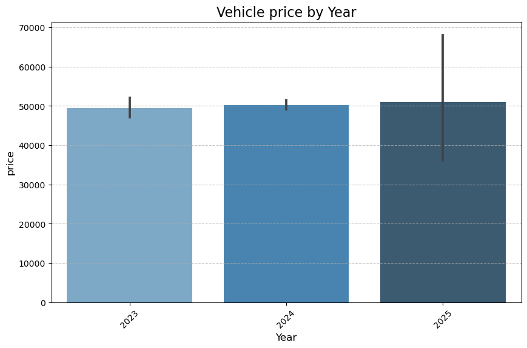

```python
import pandas as pd
import seaborn as sns
import matplotlib.pyplot as plt
plt.figure(figsize=(10, 6))
sns.barplot(x='year', y='price', data=df, palette='Blues_d')
plt.title('Vehicle price by Year', fontsize=16)
plt.xlabel('Year', fontsize=12)
plt.ylabel('price', fontsize=12)
plt.xticks(rotation=45)
plt.grid(axis='y', linestyle='--', alpha=0.7)
plt.show()
```

### Color Based on Values

[figure not shown]

```python
norm = plt.Normalize(df['price'].min(), df['price'].max())
colors = plt.cm.viridis(norm(df['price']))
plt.figure(figsize=(10, 6))
sns.barplot(x='year', y='price', data=df, palette='Blues_d', color='grey')
bars = plt.bar(df['year'], df['price'], color=colors)
plt.title('Vehicle price by Year', fontsize=16)
plt.xlabel('Year', fontsize=12)
plt.ylabel('price', fontsize=12)
plt.xticks(rotation=45)
plt.grid(axis='y', linestyle='--', alpha=0.7)
plt.show()
```

### Visualization 2:Line Chart Showing Trends in Vehicle Prices Over Time

#### Chart Type

Consider switching to a facet grid (small multiples), where each line is plotted separately in smaller charts for better comparison. Alternatively, you can use a stacked area chart to show how the total price distribution changes over time, while still representing individual model trends.

#### Color Scheme

Use a gradient-based color scheme to differentiate between lines. Avoid using too many contrasting colors—select a lighter base and use intensity to represent growth or decline.

#### Layout

Spread out the data over a larger grid, allowing for more space between the lines, or use an interactive zoom feature to allow users to focus on specific years.

#### Scaling

If the data includes outliers, apply smoothing techniques (such as a moving average) to reduce noise and make the trends clearer.

[figure not shown]

```python
plt.figure(figsize=(12, 6))
sns.lineplot(x='year', y='price', hue='model', data=df, palette='coolwarm', alpha=0.7)
df['price_smooth'] = df.groupby('model')['price'].transform(lambda x: x.rolling(3).mean())
sns.lineplot(x='year', y='price_smooth', hue='model', data=df, palette='coolwarm', linewidth=2)
plt.title('Trends in Vehicle Prices Over Time', fontsize=16)
plt.xlabel('Year', fontsize=12)
plt.ylabel('Price (in USD)', fontsize=12)
plt.xticks(rotation=45)
plt.grid(True)
plt.show()
```

### Visualization 3: Pie Chart Showing Vehicle Market Share by year

#### Chart Type

Replace the pie chart with a horizontal bar chart or stacked bar chart. These chart types are better suited for comparing values and highlighting differences year.

#### Color Scheme

Apply a sequential color scale where higher market share is represented with darker colors, making it easier to visually rank manufacturers.

###### Layout and Font Sizes

In a bar chart format, increase bar width and use large, clear font sizes for both labels and percentage values.

#### Interactivity

Add an interactive feature allowing users to click on a manufacturer to view detailed breakdowns of the models they offer, or their year-over-year price data.

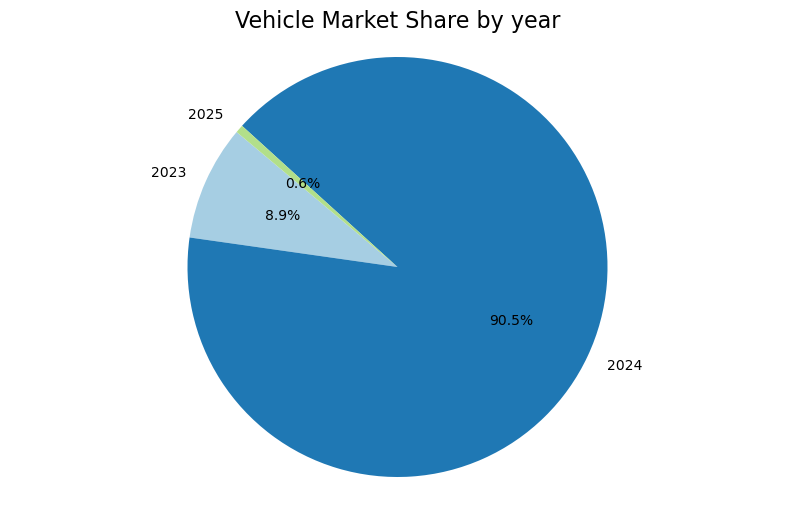

```python
import pandas as pd
import matplotlib.pyplot as plt
market_share = df.groupby('year')['price'].sum().reset_index()
labels = market_share['year']
sizes = market_share['price']
#Create the pie chart
plt.figure(figsize=(10, 6))
plt.pie(sizes, labels=labels, autopct='%1.1f%%', startangle=140, colors=plt.cm.Paired.colors)
plt.title('Vehicle Market Share by year', fontsize=16)
plt.axis('equal')
plt.show()
```

### Visualization 3: Pie Chart Showing Vehicle Market Share by model

[figure not shown]

```python
import pandas as pd
import matplotlib.pyplot as plt
market_share = df.groupby('model')['price'].sum().reset_index()
labels = market_share['model']
sizes = market_share['price']
#Create the pie chart
plt.figure(figsize=(10, 6))
plt.pie(sizes, labels=labels, autopct='%1.1f%%', startangle=140, colors=plt.cm.Paired.colors)
plt.title('Vehicle Market Share by model', fontsize=16)
plt.axis('equal')
plt.show()
```

### Visualization 4: Scatter Plot Showing Relationship Between Engine and Fuel

#### Chart Type

Consider adding a heatmap overlay to show density where data points overlap significantly. This will reveal the underlying distribution more clearly.

#### Color Scheme

Use a diverging color palette to represent different clusters of data points. Alternatively, use size or color to represent a third variable, such as vehicle type or price range.

#### Layout

Adjust the point size and transparency (alpha) to make overlapping points visible.

#### Axes

Label the axes more clearly and add gridlines to enhance readability and make it easier to compare values between different points.

[figure not shown]

```python
import pandas as pd
import seaborn as sns
import matplotlib.pyplot as plt
df['engine'] = pd.to_numeric(df['engine'], errors='coerce')
df['fuel'] = pd.to_numeric(df['fuel'], errors='coerce')
df.dropna(subset=['engine', 'fuel'], inplace=True)
if 'vehicle_type' in df.columns:
    hue_variable = 'vehicle_type'
else:
    hue_variable = None
plt.figure(figsize=(12, 8))
if hue_variable:
    sns.scatterplot(x='engine', y='fuel', data=df, hue=hue_variable, alpha=0.7, palette='viridis', s=100)
else:
    sns.scatterplot(x='engine', y='fuel', data=df, alpha=0.7, color='blue', s=100)
#Optionally add a regression line
sns.regplot(x='engine', y='fuel', data=df, scatter=False, color='red')
plt.title('Relationship Between Engine  and Fuel ', fontsize=16)
plt.xlabel('Engine(L)', fontsize=12)
plt.ylabel('Fuel (MPG)', fontsize=12)
plt.grid(True)
if hue_variable:
    plt.legend(title=hue_variable)
plt.show()
```

[figure not shown]

```python
import pandas as pd
import seaborn as sns
import matplotlib.pyplot as plt
df['price'] = pd.to_numeric(df['price'], errors='coerce')
df['fuel'] = pd.to_numeric(df['fuel'], errors='coerce')
df.dropna(subset=['price', 'fuel'], inplace=True)
if 'vehicle_type' in df.columns:
    hue_variable = 'vehicle_type'
else:
    hue_variable = None
plt.figure(figsize=(12, 8))
if hue_variable:
    sns.scatterplot(x='price', y='fuel', data=df, hue=hue_variable, alpha=0.7, palette='viridis', s=100)
else:
    sns.scatterplot(x='price', y='fuel', data=df, alpha=0.7, color='blue', s=100)
#Optionally add a regression line
sns.regplot(x='price', y='fuel', data=df, scatter=False, color='red')
plt.title('Relationship Between price and Fuel ', fontsize=16)
plt.xlabel('price(L)', fontsize=12)
plt.ylabel('Fuel (MPG)', fontsize=12)
plt.grid(True)
if hue_variable:
    plt.legend(title=hue_variable)
plt.show()
```

### Improved Histogram for Vehicle Price Distribution

#### Chart Type

Keep the histogram but increase the number of bins to reveal finer details about the price distribution.

#### Color Scheme

Use a single-color gradient where darker shades represent higher frequencies to avoid confusion with multiple colors.

#### Scaling and Layout

Ensure the x-axis (prices) is evenly scaled to avoid distorting the view. Increase the histogram width to provide more space for individual bars.

#### Labels and Titles

Provide clearer axis labels (e.g., “Price Range (in USD)”) and a title that clarifies what the viewer should look for (e.g., “Distribution of Vehicle Prices Across All Models”).

#### Interactivity

Allow users to drag a selection over specific price ranges to filter and analyze vehicles within that range. This can be combined with dynamic price statistics (e.g., average price, median price) displayed as users interact with the chart.

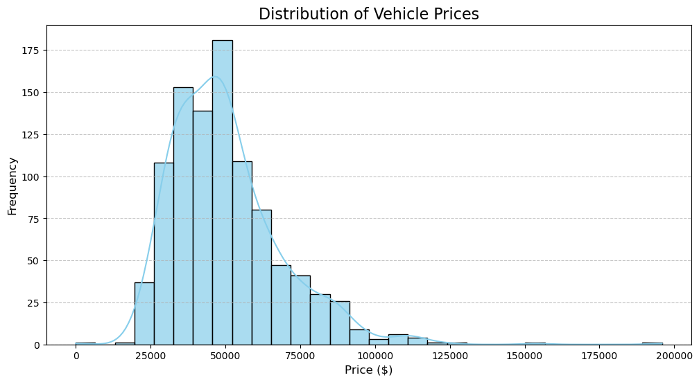

```python
import pandas as pd
import seaborn as sns
import matplotlib.pyplot as plt
df = pd.read_csv("C:\\Users\\rites\\OneDrive\\Desktop\\vehicles_dataset.csv")
df['price'] = pd.to_numeric(df['price'], errors='coerce')
df.dropna(subset=['price'], inplace=True)
plt.figure(figsize=(12, 6))
sns.histplot(df['price'], bins=30, kde=True, color='skyblue', alpha=0.7)
plt.title('Distribution of Vehicle Prices', fontsize=16)
plt.xlabel('Price ($)', fontsize=12)
plt.ylabel('Frequency', fontsize=12)
plt.grid(axis='y', linestyle='--', alpha=0.7)
plt.show()
```

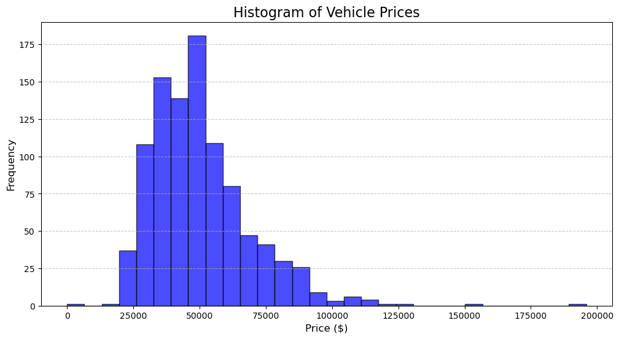

```python
import pandas as pd
import matplotlib.pyplot as plt
df['price'] = pd.to_numeric(df['price'], errors='coerce')
df.dropna(subset=['price'], inplace=True)
plt.figure(figsize=(12, 6))
# Create the histogram
plt.hist(df['price'], bins=30, color='blue', alpha=0.7, edgecolor='black')
plt.title('Histogram of Vehicle Prices', fontsize=16)
plt.xlabel('Price ($)', fontsize=12)
plt.ylabel('Frequency', fontsize=12)
plt.grid(axis='y', linestyle='--', alpha=0.7)
plt.show()
```

## Effective Visualizations

### Time Series Analysis: Line Chart

[figure not shown]

```python
import pandas as pd
import matplotlib.pyplot as plt
import seaborn as sn
df['year'] = pd.to_numeric(df['year'], errors='coerce')
df['price'] = pd.to_numeric(df['price'], errors='coerce')
df.dropna(subset=['year', 'price'], inplace=True)
# Group by year to get average price
average_price = df.groupby('year')['price'].mean().reset_index()
plt.figure(figsize=(12, 6))
sns.lineplot(x='year', y='price', data=average_price, marker='o')
plt.title('Average Vehicle Price Over Time', fontsize=16)
plt.xlabel('Year', fontsize=12)
plt.ylabel('Average Price ($)', fontsize=12)
plt.axvspan(2008, 2009, color='red', alpha=0.2, label='Economic Downturn')
plt.legend()
plt.grid()
plt.show()
```

### Heatmap for Correlation Analysis

[figure not shown]

```python
correlation_matrix = df[['engine', 'fuel', 'price', 'cylinders']].corr()
# Create a heatmap
plt.figure(figsize=(10, 6))
sns.heatmap(correlation_matrix, annot=True, cmap='coolwarm', fmt='.2f', square=True)
plt.title('Correlation Heatmap of Vehicle Features', fontsize=16)
plt.show()
```

### Interactive Dashboard Using Plotly

```python
import plotly.express as px
fig = px.scatter(df, x='engine', y='fuel', color='type',
                 title='Engine Size vs. Fuel Efficiency',
                 labels={'engine': 'Engine Size (L)', 'fuel': 'Fuel Efficiency (MPG)'})
fig.update_layout(xaxis_rangeslider_visible=True)
fig.show()
```

[interactive chart not shown]

## Insights from the New Visualizations

#### Key Findings

###### Strategic Implications:

Manufacturers and dealerships can use these insights to adapt their offerings, align marketing strategies with consumer preferences, and make data-driven decisions in product development.

###### Opportunities for Growth:

The analysis points to potential opportunities for innovation, especially in fuel-efficient and environmentally friendly vehicles, aligning with global sustainability trends.

## Exploration Assignment: Dataset Exploration and Justification

### Justification for Dataset Choice

#### Interest

Choose a dataset that resonates with your interests, whether related to business, management, finance, health, or another domain.

if you are interested in e-commerce, you might choose a dataset that tracks online sales performance or customer reviews across different platforms.

#### Relevance

Clearly establish the relevance of the dataset to a broader field like business, management, or economics.

An e-commerce dataset is relevant to business as it provides insights into consumer behavior, product popularity, and the impact of marketing strategies.

A financial dataset tracking stock market trends relates to economics, business planning, and risk management.

A dataset focused on employee performance and satisfaction could relate to HR management and organizational productivity.

#### Context

Provide background information about the dataset’s origin. Was it published by a research institution, governmental organization, or business? Include details like:

The time frame covered by the data (e.g., sales data from 2019-2023).

The method of data collection (e.g., surveys, website scraping, real-time financial reports).

Whether it has been widely cited or used in research or business cases.

#### Insight

Define the key questions or hypotheses you want to explore through this dataset.

## Divvy Analysis Dataset on Kaggle

https://www.kaggle.com/datasets/je1429387/divvy-analysis-520421

#### Interest

The dataset provides insights into bike-sharing patterns, which is particularly interesting in the context of urban mobility and sustainability.

#### Relevance

This dataset relates to urban planning, public transportation, and environmental studies, helping to analyze usage patterns and improve city infrastructure.

#### Context

The data is sourced from Divvy, a bike-sharing service in Chicago, showcasing user patterns and trends.

#### Insights

Explore questions like: What factors influence bike usage in urban areas? How can data from bike-sharing programs inform public transportation policies?

### U.S. Census Bureau Data

https://www.census.gov/ https://www.census.gov/data-tools/demo/idb/#/table?COUNTRY_YEAR=2024&COUNTRY_YR_ANIM=2024&menu=countryViz&CCODE_SINGLE=** https://www.census.gov/economic-indicators/

#### Interest

The dataset is intriguing due to its comprehensive nature, capturing various demographic and economic statistics over time.

#### Relevance

This data is crucial for understanding population dynamics, economic trends, and social indicators that affect businesses and policymaking.

#### Context

The data is collected by the U.S. Census Bureau, a reliable and authoritative source, encompassing various economic and demographic aspects.

#### Insights

Explore questions such as: How do demographic changes influence economic trends? What correlations exist between population growth and economic indicators?

### European Data Stories

https://data.europa.eu/en/publications/datastories https://data.europa.eu/en/publications/datastories/understanding-family-spending-through-data-analysis

#### Interest:

This dataset is appealing as it delves into family spending patterns, providing insights into consumer behavior and economic well-being.

##### Relevance:

Understanding family spending can inform businesses about market trends and consumer needs, aiding in product development and marketing strategies.

##### Context:

The data is sourced from various European statistical agencies, presenting a broad view of economic conditions in Europe.

###### Insights:

Investigate questions like: What are the key factors affecting family spending across different European countries? How do economic conditions influence consumer behavior?